# DTI Analysis in fslr

John Muschelli

2021-02-16

All code for this document is located at [here](https://raw.githubusercontent.com/muschellij2/neuroc/master/DTI_analysis_fslr/index.R).

# 1 Resources and Goals

Much of this work has been adapted by the FSL guide for DTI: http://fsl.fmrib.ox.ac.uk/fsl/fslwiki/FDT/UserGuide. We will show you a few steps that have been implemented in `fslr`: `eddy_correct` and `dtifit`. Although `xfibres` has been adapted for `fslr`, which is the backend for `bedpostx` from FSL, it takes a long time to run and the results are not seen in this vignette, though code is given to illustrate how it would be run.

# 2 Data Packages

For this analysis, I will use one subject from the Kirby 21 data set. The `kirby21.base` and `kirby21.dti` packages are necessary for this analysis and have the data we will be working on. You need devtools to install these. Please refer to installing devtools for additional instructions or troubleshooting.

```r
packages = installed.packages()
packages = packages[, "Package"]
if (!"kirby21.base" %in% packages) {
  source("https://neuroconductor.org/neurocLite.R")
  neuroc_install("kirby21.base")
}
if (!"kirby21.dti" %in% packages) {
  source("https://neuroconductor.org/neurocLite.R")
  neuroc_install("kirby21.dti")
}
```

# 3 Loading Data

We will use the `get_image_filenames_df` function to extract the filenames on our hard disk for the T1 image.

```r
library(kirby21.dti)
library(kirby21.base)
download_dti_data()
```

```
## [1] TRUE
```

```r
fnames = get_image_filenames_df(ids = 113,
                    modalities = c("T1", "DTI"),
                    visits = c(1),
                    long = FALSE)
t1_fname = fnames$T1[1]
dti_fname = fnames$DTI[1]
base_fname = nii.stub(dti_fname, bn = TRUE)
dti_data = get_dti_info_filenames(
  ids = 113,
  visits = c(1))
b_fname = dti_data$fname[ dti_data$type %in% "b"]
grad_fname = dti_data$fname[ dti_data$type %in% "grad"]
```

## 3.1 Making b-vectors and b-values

As `dtifit` requires the b-values and b-vectors to be separated, we will take a look at this data.

```r
b_vals = readLines(b_fname)
b_vals = as.numeric(b_vals)
b0 = which(b_vals == 0)[1]

b_vecs = read.delim(grad_fname, header = FALSE)
stopifnot(all(is.na(b_vecs$V4)))
b_vecs$V4 = NULL
colnames(b_vecs) = c("x", "y", "z")
```

## 3.2 Printing out FSL Version

```r
library(fslr)
print(fsl_version())
```

```
## [1] "6.0.4"
```

## 3.3 Checking our data

Here we ensure that the number of b-values/b-vectors is the same as the number of time points in the 4D image.

```r
n_timepoints = fslval(dti_fname, "dim4")
```

```
## fslval "/Users/johnmuschelli/Library/R/4.0/library/kirby21.dti/visit_1/113/113-01-DTI.nii.gz" dim4
```

```r
stopifnot(nrow(b_vecs) == n_timepoints)
stopifnot(length(b_vals) == n_timepoints)
```

# 4 Running `eddy_correct`

Here, we will run an eddy current correction using FSL’s `eddy_correct` through `fslr`. We will save the result in a temporary file (`outfile`), but also return the result as a `nifti` object `ret`, as `retimg = TRUE`. We will use the first volume as the reference as is the default in FSL. *Note* FSL is zero-indexed so the first volume is the zero-ith index:

```r
eddy_fname = paste0(base_fname, "_eddy.nii.gz")
if (!file.exists(eddy_fname)) {
  eddy = eddy_correct(
    infile = dti_fname,
    outfile = eddy_fname,
    retimg = TRUE,
    reference_no = 0)
} else {
  eddy = readnii(eddy_fname)
}
```

Let’s look at the eddy current-corrected (left) and the non-corrected data (right). Here we will look at the image where the b-value is equal to zero.

```r
dti = readnii(dti_fname)
eddy0 = extrantsr::subset_4d(eddy, b0)
dti0 = extrantsr::subset_4d(dti, b0)
```

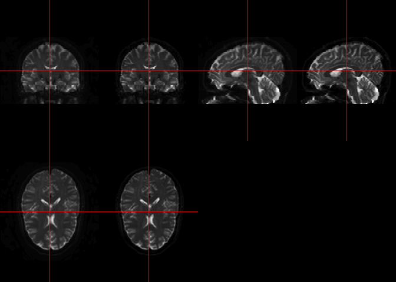

```r
double_ortho(robust_window(eddy0), robust_window(dti0))
```

Note, from here on forward we will use either the filename for the output of the eddy current correction or the eddy-current-corrected `nifti` object.

# 5 Getting a brain mask

```r
mask_fname = paste0(base_fname, "_mask.nii.gz")
if (!file.exists(mask_fname)) {
  fsl_bet(infile = dti0, outfile = mask_fname)
}
mask = readnii(mask_fname)
```

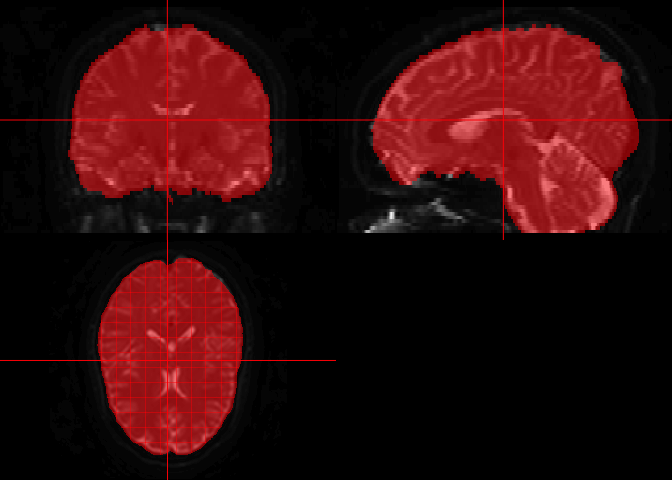

```r
ortho2(robust_window(dti0), mask, col.y = alpha("red", 0.5))
```